# Risk Factor Analysis for Equity Returns During Covid

**Goal**: The Goal of this anlysis is to show optimal firm structure ahead of the COVID-19 crises. Specifically, I analyze firm Financing, Operating, and Investing activity prior to the crises and compare these measures to equity returns during the crisis. This will show which firms were best and worst positioned

**Methodology**: I gather data from firms in the S&P 500. Specifically, I analyze Firm's 10-Ks using basic Natural Language Processing to search for key phrases and terms that would indicate certain risk factors. I then look at firm accounting data and its relation with equity returns. The combination of these measures should indicate the optimal stucture.

**Data**: 10-K's are collected from SEC Edgar. Firm accounting data is provided. The complete analysis considers 352 firms across various industries and subsectors

**Conclusions**: Companies with less debt in their Capital Structure and more effort put into New Product Development and R&D Tended to outperform during COVID

```python
'''
Packages used
'''
import pandas as pd
import matplotlib.pyplot as plt
import seaborn as sns
```

```python
'''
load data
'''
risk_return = pd.read_csv('risk_and_return_by_week.csv', index_col='Unnamed: 0')
```

## Top Down Data Analysis

**Text Risk Ractors**: Text risk factors measures mentions of phrases associated with the following ideas. I group the types of these similar to a firm's Cash Flow statement (financing, operating, and investing), as an event like COVID should kill firm's Cash Flows. I then look at the correlation of these risk measures against returns week over week of 2020 (week 10 being the first week of March). The relationship between these should then show optimal firm structure leading into the crisis. I define the words to be "close" if they are within 30 words of each other.

- *Financing*: Interest Rate Risk - Measures risks associated with interest rate moves, looks for the words 'rate' and 'risk' to be close to each other.
- *Financing*: Credit Risk - Measures risks associated with debt, looks for the words 'debt' and 'risk' to be close to each other.
- *Financing*: Credit Capacity - Measures mentions of firms drawing down lines of credit, looks for the words 'credit facility' and 'draw' to be close to each other (i.e. looking for the phrase "draw down on the credit facility").
- *Operating*: Product Risk - Measures firms mentioning new products, looks for the words 'new' and 'product' to be close to each other
- *Operating*: Wage Risk - Measures firms mentioning increasing wages, looks for the words 'increase' and 'wage' to be close to each other.
- *Operating*: Maintenance - Measures firms mentioning maintenance costs, looks for the words 'maintenance' and 'cost' to be close to each other.
- *Investing*: CAPEX - Measures firms mentioning growth CAPEX, looks for the words 'capital', 'expenditures', and 'growth' to be close to each other (i.e. measuring firms spending money to grow).

**Accounting Risk Factors**: Accounting measures to proxy similar activities to the text risk factors. Financing shows firm leverage, operating shows size, and investing shows money put into future activities.

- *Financing*: Total Debt Ratio - Debt to Assets
- *Financing*: Total Debt to Market - Debt to Market Value
- *Operating*: Log of Employee Count - Measures firm employees
- *Investing*: R&D Ratio - R&D to Assets

### Exploratory Data Analysis

**Text Measures**  
*Data Set*

- Consistent length (352)
- Good data spread over most categories (large standard deviations relative to means)
- Some measures have very small means (credit capacity and capex), indicating they may be better used in categorical statistical tests

*Validity*

- Financing Risk - The least present variable shows up when other keys show up
- Operating Risk - A pharmacuetical company produces lots of new products
- Investing Risk - FedEx and Norwegian are massive companies and should have large CAPEX

**Accounting Measures**  
*Data Set*

- Consistent Length (352)

*Validity*

- Data min 0s and no excessively large maxes

**Conclusion**: Data is sufficient to proceed with analysis

```python
'''
DATA EDA

Accounting Data and Returns
---
    FINANCING
    - td_a - Total Debt Ratio
    - td_mv - Total Debt to Market
    OPERATING
    - l_emp - Log of Employees
    INVESTING
    - xrd_a - R&D Ratio
'''
acct_factors = ['td_a', 'td_mv', 'l_emp', 'xrd_a']
text_factors = ['interest_rate_risk', 'credit_risk', 'credit_capacity', 'product_risk', 'wage_risk','maintenance', 'capex']
```

```python
'''Text Risk Factors & EDA'''
risk_return[text_factors].describe()
```

|  | interest_rate_risk | credit_risk | credit_capacity | product_risk | wage_risk | maintenance | capex |
| --- | --- | --- | --- | --- | --- | --- | --- |
| count | 352.000000 | 352.000000 | 352.000000 | 352.000000 | 352.000000 | 352.000000 | 352.000000 |
| mean | 6.534091 | 2.400568 | 0.181818 | 6.423295 | 0.213068 | 0.829545 | 0.630682 |
| std | 5.002447 | 2.342789 | 0.867855 | 7.271285 | 0.786314 | 1.251521 | 1.034984 |
| min | 0.000000 | 0.000000 | 0.000000 | 0.000000 | 0.000000 | 0.000000 | 0.000000 |
| 25% | 3.000000 | 1.000000 | 0.000000 | 1.000000 | 0.000000 | 0.000000 | 0.000000 |
| 50% | 6.000000 | 2.000000 | 0.000000 | 4.000000 | 0.000000 | 0.000000 | 0.000000 |
| 75% | 8.000000 | 4.000000 | 0.000000 | 9.000000 | 0.000000 | 1.000000 | 1.000000 |
| max | 39.000000 | 14.000000 | 12.000000 | 47.000000 | 9.000000 | 8.000000 | 5.000000 |

```python
'''
Credit Risk
---
LYV - Live Nation
'''
risk_return[risk_return['credit_capacity'] == risk_return.credit_capacity.max()].iloc[:,-7:]
```

|  | interest_rate_risk | credit_risk | credit_capacity | product_risk | wage_risk | maintenance | capex |
| --- | --- | --- | --- | --- | --- | --- | --- |
| LYV | 6 | 1 | 12 | 0 | 0 | 1 | 0 |

```python
'''
Product Risk
---
REGN - Regeneron Pharma
'''
risk_return[risk_return['product_risk'] == risk_return.product_risk.max()].iloc[:,-7:]
```

|  | interest_rate_risk | credit_risk | credit_capacity | product_risk | wage_risk | maintenance | capex |
| --- | --- | --- | --- | --- | --- | --- | --- |
| REGN | 3 | 1 | 0 | 47 | 0 | 2 | 0 |

```python
'''
Capex Validation
---
FDX - FedEx
NCLH - Norwegian Cruise Line
TSCO - Tractor Supply Co
'''
risk_return[risk_return['capex'] == risk_return.capex.max()].iloc[:,-7:]
```

|  | interest_rate_risk | credit_risk | credit_capacity | product_risk | wage_risk | maintenance | capex |
| --- | --- | --- | --- | --- | --- | --- | --- |
| FDX | 5 | 3 | 0 | 1 | 0 | 0 | 5 |
| NCLH | 5 | 1 | 0 | 4 | 0 | 2 | 5 |
| TSCO | 10 | 1 | 0 | 4 | 1 | 0 | 5 |

```python
'''Accounting Measures & EDA'''
risk_return[acct_factors].describe()
```

|  | td_a | td_mv | l_emp | xrd_a |
| --- | --- | --- | --- | --- |
| count | 352.000000 | 352.000000 | 352.000000 | 352.000000 |
| mean | 0.328435 | 0.185137 | 3.327105 | 0.031364 |
| std | 0.192516 | 0.140769 | 1.160559 | 0.050330 |
| min | 0.000000 | 0.000000 | 0.455524 | 0.000000 |
| 25% | 0.204722 | 0.092256 | 2.440164 | 0.000000 |
| 50% | 0.319227 | 0.160139 | 3.263833 | 0.009533 |
| 75% | 0.432302 | 0.262688 | 4.197118 | 0.043306 |
| max | 1.245754 | 0.809531 | 6.025866 | 0.336795 |

### Text Risk Factors Correlation with Returns

Credit Risk and New Product Risk showing strongest correlations through time

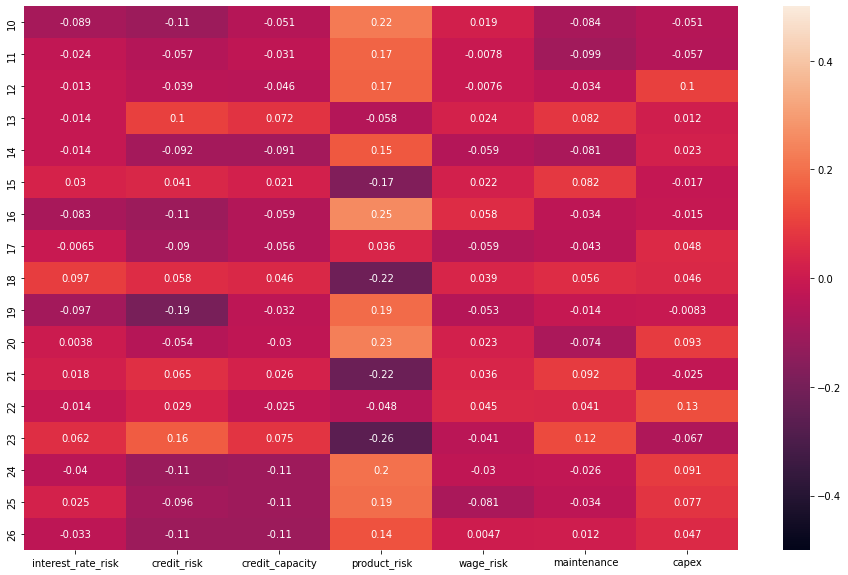

```python
'''
Text Risk Factors and Returns
'''
plt.figure(figsize=(16,10))
sns.heatmap(risk_return.corr().iloc[:17,-7:], annot=True, vmin=-0.5, vmax=0.5)
```

### Accounting Risk Factors Correlation With Returns

Debt and R&D Correlated strongly with returns over time

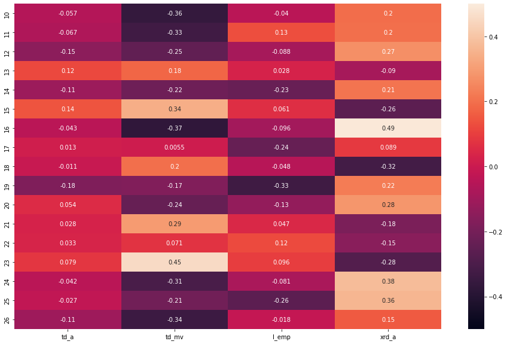

```python
plt.figure(figsize=(16,10))
sns.heatmap(risk_return.corr().loc[acct_factors].iloc[:,:17].transpose(), annot=True, vmin=-0.5, vmax=0.5)
```

## Drawing Conclusions

**Events**

- Crisis Week - Week 11 was 3/9/20 to 3/15/20
- Other weeks included around the crisis data

**Risk Factor Inter-Relations**

- As expected, Credit Risk is correlated with Total Debt
- As expected, Product Risk is correlated with R&D
- Unexpected, Product Risk is correlated with Total Debt, but not Credit Risk
- Unexpected, R&D is Correlated with Total Debt

**Risk Factor Return Relations**

**Graphic Relationships**

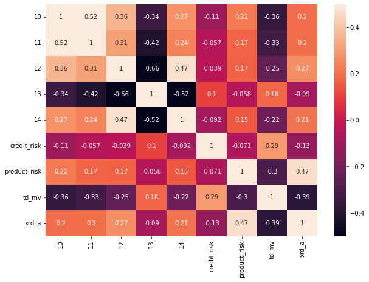

```python
facts = ['10','11','12','13','14','credit_risk', 'product_risk', 'td_mv', 'xrd_a']
plt.figure(figsize=(10,7))
sns.heatmap(risk_return[facts].corr(), annot=True, vmin=-0.5, vmax=0.5)
```

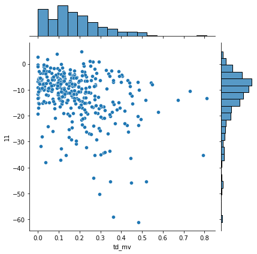

```python
'''Debt and Returns, week 11'''
sns.jointplot(y='11',x='td_mv',data=risk_return)
```

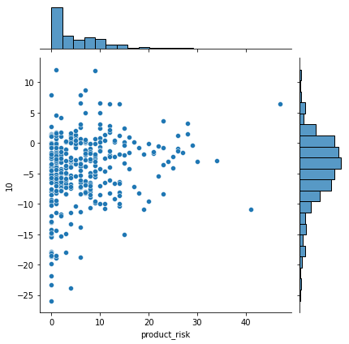

```python
'''Product risk and Returns, week 10'''
sns.jointplot(y='10',x='product_risk',data=risk_return)
```

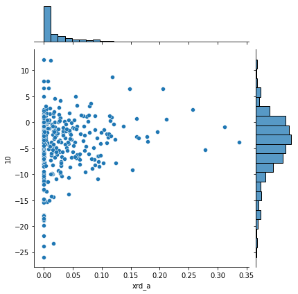

```python
'''Product risk and Returns, week 10'''
sns.jointplot(y='10',x='xrd_a',data=risk_return)
```

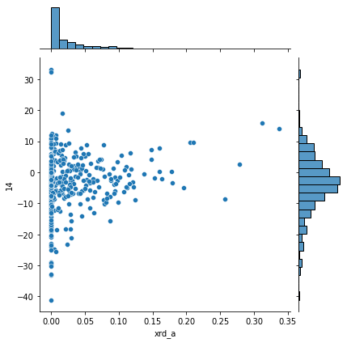

```python
'''Credit Risk and Returns, week 10'''
sns.jointplot(y='14',x='xrd_a',data=risk_return)
```